# The Evolution of Movie Trends - Part II

```python
import pandas as pd
import matplotlib.pyplot as plt
import seaborn as sns
import statsmodels.api as sm
import statsmodels.formula.api as smf
from scipy.stats import chi2_contingency, chi2
```

```python
# import cleaned dataset(cleaning process in Part I)
df = pd.read_csv("data/cleaned_df.csv")
```

```python
df.head(1)
```

|  | titles | date | score | genre | overview | crew | orig_title | orig_lang | budget | revenue | ... | Crime | Horror | Mystery | History | War | Documentary | Romance | Music | Western | TV Movie |
| --- | --- | --- | --- | --- | --- | --- | --- | --- | --- | --- | --- | --- | --- | --- | --- | --- | --- | --- | --- | --- | --- |
| 0 | Creed III | 2023-03-02 | 73.0 | Drama, Action | After dominating the boxing world, Adonis Cree... | Michael B. Jordan, Adonis Creed, Tessa Thompso... | Creed III | English | 75000000.0 | 271616668.0 | ... | 0.0 | 0.0 | 0.0 | 0.0 | 0.0 | 0.0 | 0.0 | 0.0 | 0.0 | 0.0 |

1 rows × 44 columns

```python
df.columns
```

```
Index(['titles', 'date', 'score', 'genre', 'overview', 'crew', 'orig_title',
       'orig_lang', 'budget', 'revenue', 'country', 'show_id', 'director',
       'cast', 'date_added', 'rating', 'duration(min)', 'listed_in',
       'description', 'app', 'main_cast_1', 'main_cast_2', 'year',
       'year_group', 'year_group_label', 'Drama', 'Action', 'Science Fiction',
       'Adventure', 'Animation', 'Family', 'Fantasy', 'Comedy', 'Thriller',
       'Crime', 'Horror', 'Mystery', 'History', 'War', 'Documentary',
       'Romance', 'Music', 'Western', 'TV Movie'],
      dtype='object')
```

## Descriptive statistics

**The Questions we would like to answer:**

1. What are the differences in people's preferences for genres of movies over time?
2. What are the main factors that influence the box office?
3. Do streaming platforms show specific preferences in the genres of movies they make available?

### Question 1

In addressing the first question(differences in people’s preferences for movie genres over time), we first examine the distribution of release years.

```python
df['year'].describe()
```

```
count    11285.00000
mean      2007.43899
std         15.75490
min       1903.00000
25%       2001.00000
50%       2012.00000
75%       2019.00000
max       2023.00000
Name: year, dtype: float64
```

```python
print(f"The most frequent year label: {df['year_group_label'].mode().values[0]}")
```

```
The most frequent year label: 2016-2020
```

The dataset spans 1903–2023, with a 25th percentile of 2001, a median of 2012 and a 75th percentile of 2019. In other words, only one-quarter of the movies were released in the first 100 years, half of the movies were released after 2012, and one-quarter after 2019. Although the range covers about 120 years, releases are skewed toward recent years, with most movies produced between 2016 and 2020.

### Question 2

To address the second questions, to find out the main factors that influence the box office, we would like to first examine the distribution of box office.

```python
df['revenue'].describe()
```

```
count    1.128500e+04
mean     2.494507e+08
std      2.791863e+08
min      0.000000e+00
25%      2.935520e+07
50%      1.414753e+08
75%      4.103658e+08
max      2.923706e+09
Name: revenue, dtype: float64
```

```python
print(f"The standard deviation of box office revenue: {df['revenue'].std()}")
```

```
The standard deviation of box office revenue: 279186303.049238
```

For the next step, we would like to do the descriptive analysis to the factors that might affect the box office:

```python
df[['score','budget','duration(min)']].describe()
```

|  | score | budget | duration(min) |
| --- | --- | --- | --- |
| count | 11285.000000 | 1.128500e+04 | 3238.000000 |
| mean | 63.687638 | 6.370894e+07 | 103.692094 |
| std | 13.167976 | 5.734963e+07 | 22.589841 |
| min | 0.000000 | 1.000000e+00 | 3.000000 |
| 25% | 59.000000 | 1.380000e+07 | 91.000000 |
| 50% | 65.000000 | 4.727000e+07 | 101.000000 |
| 75% | 71.000000 | 1.036000e+08 | 115.000000 |
| max | 100.000000 | 4.600000e+08 | 312.000000 |

```python
df[['score','budget','duration(min)']].std()
```

```
score            1.316798e+01
budget           5.734963e+07
duration(min)    2.258984e+01
dtype: float64
```

**Budget**

There are 11,285 films with budgets. The mean is $63.71 Million, and the standard deviation is $57.35 Million, indicating substantial dispersion. The median ($47.27M) is below the mean; together with the quartiles ($13.8M at 25% and $103.6M at 75%) and a maximum of $460M, this points to a strong right skew driven by a small number of very high-budget titles.

**Duration (minutes)**

There are only 3,238 films have duration, which indicated a great number of missing values. The mean is 103.70 minutes and the standard deviation is 22.59 minutes. The median is 101 minutes, with an IQR of 91–115, which is consistent with typical movie duration (about 1.5–2 hours). The maximum (312 minutes) suggests a few very long films, while the minimum (3 minutes) might indicates error data.

### Question 3

To examine whether streaming platforms show preferences for specific movie genres, we begin by analyzing the genre composition of films in our dataset.

```python
# Calculate the average scores for each genre
all_genres = df['genre'].dropna().str.split(',').explode().str.strip().unique()
df[all_genres].mean().sort_values(ascending=False)
```

```
Drama              0.374214
Comedy             0.279486
Action             0.265219
Thriller           0.257776
Adventure          0.190341
Romance            0.161808
Horror             0.157200
Fantasy            0.151794
Family             0.150731
Animation          0.144085
Science Fiction    0.123261
Crime              0.122463
Mystery            0.083031
History            0.040496
War                0.026673
Music              0.026584
TV Movie           0.020735
Documentary        0.019761
Western            0.012140
dtype: float64
```

```python
print(f"The sum of mean values across all genres:{df[all_genres].mean().sum()}")
```

```
The sum of mean values across all genres:2.6077979618963223
```

The sum of mean values across all genres exceeds 1, indicating that movies can belong to multiple genres. The three most common genres are Drama (37%), Comedy (28%), and Action (27%), while the least common are TV Movie (2%), Documentary (2%), and Western (1%).

## Inferential statistics

In this part, we will use 0.05 as our significant level.

### Question 1: What are the differences in people's preferences for genres of movies over time?

To assess whether people's preference in genres of movies changes over time, we will run a chi-square test of independence on the year_label × genre contingency table across the three platforms.

$H_0$: People's preference in $genre_j$ DOES NOT change over time.

$H_1$: People's preference in $genre_j$ DOES change over time.

```python
# all genres list
all_genres = df['genre'].dropna().str.split(',').explode().str.strip().unique()
all_genres = all_genres.tolist()
all_genres
```

```
['Drama',
 'Action',
 'Science Fiction',
 'Adventure',
 'Animation',
 'Family',
 'Fantasy',
 'Comedy',
 'Thriller',
 'Crime',
 'Horror',
 'Mystery',
 'History',
 'War',
 'Documentary',
 'Romance',
 'Music',
 'Western',
 'TV Movie']
```

```python
# Perform chi-squared tests for each genre across time periods
chi2_time_results = {}
print(f"{'Genre':<20} {'Chi² Statistic':<15} {'P-value':<12} {'Significant':<12}")
print("-" * 65)

significant_time_genres = []
time_periods = df['year_group_label'].unique()
for genre in all_genres:
    # Create contingency table for current genre vs time periods
    contingency_table = pd.crosstab(
        df[genre],
        df['year_group_label'],
        margins=False
    )

    # Only proceed if we have both 0s and 1s for this genre
    if len(contingency_table) == 2:  # Should have both 0 and 1 rows
        # Perform chi-squared test
        chi2_stat, p_value, dof, expected = chi2_contingency(contingency_table)

        # Store results
        chi2_time_results[genre] = {
            'chi2_statistic': chi2_stat,
            'p_value': p_value,
            'degrees_of_freedom': dof,
            'contingency_table': contingency_table,
            'expected': expected,
            'significant': p_value < 0.05
        }

        if p_value < 0.05:
            significant_time_genres.append(genre)

        # Display results
        p_display = f"{p_value:.2e}" if p_value < 0.001 else f"{p_value:.6f}"
        print(f"{genre:<20} {chi2_stat:<15.4f} {p_display:<12} {'Yes' if p_value < 0.05 else 'No':<12}")

    else:
        print(f"{genre:<20} {'Insufficient variation':<40}")

print(f"\nSummary: {len(significant_time_genres)} out of {len(chi2_time_results)} \genres show significant time period associations (p < 0.05)")
```

```
Genre                Chi² Statistic  P-value      Significant
-----------------------------------------------------------------
Drama                112.1416        2.38e-13     Yes
Action               139.1006        3.41e-18     Yes
Science Fiction      84.0174         1.38e-08     Yes
Adventure            139.8177        2.52e-18     Yes
Animation            264.7945        1.89e-42     Yes
Family               238.6226        2.94e-37     Yes
Fantasy              158.0903        1.02e-21     Yes
Comedy               144.1128        4.08e-19     Yes
Thriller             73.7571         5.82e-07     Yes
Crime                81.3092         3.76e-08     Yes
Horror               147.7587        8.63e-20     Yes
Mystery              84.4841         1.16e-08     Yes
History              256.2740        9.39e-41     Yes
War                  244.2173        2.30e-38     Yes
Documentary          166.1510        3.12e-23     Yes
Romance              142.7470        7.28e-19     Yes
Music                13.6236         0.954700     No
Western              502.6281        4.75e-91     Yes
TV Movie             42.9996         0.009948     Yes

Summary: 18 out of 19 \genres show significant time period associations (p < 0.05)
```

We find that 18 of 19 genres show a significant association with year group (p<0.05). Music is the only non-significant case (p=0.955).  
For those 18 genres, we reject $H_0$ and conclude there is a statistically significant relationship between genre and year group.  
For Music, we fail to reject $H_0$. In other words, we can not reject the hypothesis that "People's preference in $genre_j$ DOES NOT change over time".

### Question 2: What are the main factors that influence the box office?

#### Model 0: Base Model

To examine which factors influence box office performance, We will begin with a full model that includes IMDb score (score), production budget (budget), runtime (duration(min)), release year (year), film rating (rating), and a set of genre dummy variables.

```python
# Include all genres as predictors
genre_formula = " + ".join([f"Q('{genre}')" for genre in all_genres])
model0 = smf.ols(f"revenue ~ score + budget + Q('duration(min)') + year + rating + {genre_formula} ", data=df).fit()
model0.summary()
```

OLS Regression Results

| Dep. Variable: | revenue | R-squared: | 0.563 |
| --- | --- | --- | --- |
| Model: | OLS | Adj. R-squared: | 0.557 |
| Method: | Least Squares | F-statistic: | 91.50 |
| Date: | Sat, 01 Nov 2025 | Prob (F-statistic): | 0.00 |
| Time: | 18:14:53 | Log-Likelihood: | -66094. |
| No. Observations: | 3238 | AIC: | 1.323e+05 |
| Df Residuals: | 3192 | BIC: | 1.326e+05 |
| Df Model: | 45 |  |  |
| Covariance Type: | nonrobust |  |  |

|  | coef | std err | t | P>\|t\| | [0.025 | 0.975] |
| --- | --- | --- | --- | --- | --- | --- |
| Intercept | 3.139e+08 | 4.62e+08 | 0.679 | 0.497 | -5.93e+08 | 1.22e+09 |
| rating[T.16+] | 3.505e+07 | 2.54e+07 | 1.378 | 0.168 | -1.48e+07 | 8.49e+07 |
| rating[T.18+] | 3.559e+07 | 3.3e+07 | 1.078 | 0.281 | -2.91e+07 | 1e+08 |
| rating[T.7+] | 5.055e+07 | 4.32e+07 | 1.171 | 0.242 | -3.41e+07 | 1.35e+08 |
| rating[T.AGES_16_] | -2.756e+07 | 1.28e+08 | -0.214 | 0.830 | -2.79e+08 | 2.24e+08 |
| rating[T.AGES_18_] | 3.395e+07 | 1.8e+08 | 0.189 | 0.850 | -3.19e+08 | 3.86e+08 |
| rating[T.ALL] | 5.551e+07 | 3.95e+07 | 1.406 | 0.160 | -2.19e+07 | 1.33e+08 |
| rating[T.G] | 2.436e+07 | 2.4e+07 | 1.014 | 0.310 | -2.27e+07 | 7.14e+07 |
| rating[T.NC-17] | -7.843e+07 | 1.8e+08 | -0.435 | 0.664 | -4.32e+08 | 2.75e+08 |
| rating[T.NR] | 2.228e+07 | 5.35e+07 | 0.416 | 0.677 | -8.27e+07 | 1.27e+08 |
| rating[T.Not Rated] | 2.504e+07 | 5.02e+07 | 0.499 | 0.618 | -7.34e+07 | 1.23e+08 |
| rating[T.PG] | 5.048e+07 | 2.24e+07 | 2.257 | 0.024 | 6.63e+06 | 9.43e+07 |
| rating[T.PG-13] | -1.176e+06 | 2.09e+07 | -0.056 | 0.955 | -4.21e+07 | 3.97e+07 |
| rating[T.R] | 2.413e+07 | 2.02e+07 | 1.192 | 0.233 | -1.56e+07 | 6.38e+07 |
| rating[T.TV-14] | 2.858e+07 | 2.57e+07 | 1.111 | 0.267 | -2.19e+07 | 7.9e+07 |
| rating[T.TV-G] | 1.135e+08 | 3.59e+07 | 3.160 | 0.002 | 4.31e+07 | 1.84e+08 |
| rating[T.TV-MA] | 5.542e+07 | 2.21e+07 | 2.505 | 0.012 | 1.2e+07 | 9.88e+07 |
| rating[T.TV-PG] | 5.62e+07 | 2.84e+07 | 1.981 | 0.048 | 5.63e+05 | 1.12e+08 |
| rating[T.TV-Y] | 8.495e+07 | 4.92e+07 | 1.728 | 0.084 | -1.14e+07 | 1.81e+08 |
| rating[T.TV-Y7] | 8.375e+07 | 3.84e+07 | 2.181 | 0.029 | 8.46e+06 | 1.59e+08 |
| rating[T.TV-Y7-FV] | -4.375e+07 | 1.31e+08 | -0.333 | 0.739 | -3.01e+08 | 2.14e+08 |
| rating[T.UNRATED] | -8.756e+07 | 9.18e+07 | -0.953 | 0.340 | -2.68e+08 | 9.25e+07 |
| rating[T.UR] | 3.497e+07 | 1.05e+08 | 0.333 | 0.739 | -1.71e+08 | 2.41e+08 |
| score | 4.601e+06 | 4.35e+05 | 10.588 | 0.000 | 3.75e+06 | 5.45e+06 |
| budget | 3.5251 | 0.064 | 55.056 | 0.000 | 3.400 | 3.651 |
| Q('duration(min)') | -1.819e+05 | 1.72e+05 | -1.060 | 0.289 | -5.18e+05 | 1.55e+05 |
| year | -2.864e+05 | 2.28e+05 | -1.259 | 0.208 | -7.32e+05 | 1.6e+05 |
| Q('Drama') | -2.036e+07 | 8.06e+06 | -2.527 | 0.012 | -3.62e+07 | -4.56e+06 |
| Q('Action') | -2.149e+07 | 8.91e+06 | -2.413 | 0.016 | -3.9e+07 | -4.03e+06 |
| Q('Science Fiction') | -9.651e+06 | 1.07e+07 | -0.904 | 0.366 | -3.06e+07 | 1.13e+07 |
| Q('Adventure') | -6.058e+07 | 9.11e+06 | -6.651 | 0.000 | -7.84e+07 | -4.27e+07 |
| Q('Animation') | -6.035e+06 | 1.21e+07 | -0.499 | 0.618 | -2.97e+07 | 1.77e+07 |
| Q('Family') | -3.141e+06 | 1.29e+07 | -0.244 | 0.807 | -2.84e+07 | 2.21e+07 |
| Q('Fantasy') | 3.012e+07 | 8.9e+06 | 3.383 | 0.001 | 1.27e+07 | 4.76e+07 |
| Q('Comedy') | -4.071e+07 | 8.21e+06 | -4.961 | 0.000 | -5.68e+07 | -2.46e+07 |
| Q('Thriller') | -1.205e+07 | 9.06e+06 | -1.331 | 0.183 | -2.98e+07 | 5.71e+06 |
| Q('Crime') | -2.228e+07 | 1.08e+07 | -2.062 | 0.039 | -4.35e+07 | -1.1e+06 |
| Q('Horror') | 1.399e+07 | 1.13e+07 | 1.238 | 0.216 | -8.16e+06 | 3.61e+07 |
| Q('Mystery') | -8.734e+06 | 1.27e+07 | -0.687 | 0.492 | -3.37e+07 | 1.62e+07 |
| Q('History') | -2.744e+07 | 1.75e+07 | -1.568 | 0.117 | -6.18e+07 | 6.88e+06 |
| Q('War') | -4.462e+07 | 2.11e+07 | -2.117 | 0.034 | -8.59e+07 | -3.29e+06 |
| Q('Documentary') | 6.094e+07 | 3.17e+07 | 1.920 | 0.055 | -1.3e+06 | 1.23e+08 |
| Q('Romance') | 6.236e+07 | 9.58e+06 | 6.512 | 0.000 | 4.36e+07 | 8.11e+07 |
| Q('Music') | -2.456e+07 | 2e+07 | -1.226 | 0.220 | -6.38e+07 | 1.47e+07 |
| Q('Western') | 1.829e+06 | 3.07e+07 | 0.060 | 0.952 | -5.83e+07 | 6.2e+07 |
| Q('TV Movie') | 9.233e+07 | 2.3e+07 | 4.009 | 0.000 | 4.72e+07 | 1.37e+08 |

| Omnibus: | 1104.924 | Durbin-Watson: | 1.420 |
| --- | --- | --- | --- |
| Prob(Omnibus): | 0.000 | Jarque-Bera (JB): | 11188.696 |
| Skew: | 1.323 | Prob(JB): | 0.00 |
| Kurtosis: | 11.714 | Cond. No. | 1.16e+10 |

Notes:  
[1] Standard Errors assume that the covariance matrix of the errors is correctly specified.  
[2] The condition number is large, 1.16e+10. This might indicate that there are  
strong multicollinearity or other numerical problems.

$$ H_0:\ \beta_j = 0 \quad\text{(no effect of variable $j$ on box office)} $$

$$ H_1:\ \beta_j \neq 0 \quad\text{(variable $j$ affects box office)} $$ In words: for each predictor $X_j$, the null hypothesis states that its coefficient is zero (it does not affect box-office revenue). The alternative hypothesis is that the coefficient is nonzero (it does affect box-office revenue). We will test at a 0.05 significance level and reject $H_0$ when the p-value is < 0.05.

**Model fit**  
The model’s $R^2 = 0.563$, so about 56.3% of the variance in box office is explained by the included predictors. The Prob(F-stat) is effectively 0.00 (i.e., p < 0.01), indicating the model is jointly significant.

**Score and Budget**  
Both variables have p < 0.01, indicating statistically significant associations with box office.

**Duration and Year**  
Both show p > 0.05, so we lack evidence to reject $H_0$ for these terms. I’ll remove them in the next model specification.

**Genre dummies**  
Among the genre dummies, some are statistically significant at the 0.05 significance level while others are not. I’ll keep the full set in the next model and re-evaluate their p-values, removing any that remain non-significant.

#### Model 1

My second model will include IMDb score (score), production budget (budget) and a set of genre dummy variables.

```python
model1 = smf.ols(f"revenue ~ score + budget + {genre_formula}", data=df).fit()
model1.summary()
```

OLS Regression Results

| Dep. Variable: | revenue | R-squared: | 0.538 |
| --- | --- | --- | --- |
| Model: | OLS | Adj. R-squared: | 0.538 |
| Method: | Least Squares | F-statistic: | 625.5 |
| Date: | Sat, 01 Nov 2025 | Prob (F-statistic): | 0.00 |
| Time: | 18:14:53 | Log-Likelihood: | -2.3111e+05 |
| No. Observations: | 11285 | AIC: | 4.623e+05 |
| Df Residuals: | 11263 | BIC: | 4.624e+05 |
| Df Model: | 21 |  |  |
| Covariance Type: | nonrobust |  |  |

|  | coef | std err | t | P>\|t\| | [0.025 | 0.975] |
| --- | --- | --- | --- | --- | --- | --- |
| Intercept | -3.162e+08 | 1.08e+07 | -29.322 | 0.000 | -3.37e+08 | -2.95e+08 |
| score | 5.792e+06 | 1.47e+05 | 39.311 | 0.000 | 5.5e+06 | 6.08e+06 |
| budget | 3.5280 | 0.034 | 104.706 | 0.000 | 3.462 | 3.594 |
| Q('Drama') | -2.28e+07 | 4.51e+06 | -5.055 | 0.000 | -3.16e+07 | -1.4e+07 |
| Q('Action') | -2.546e+07 | 4.83e+06 | -5.270 | 0.000 | -3.49e+07 | -1.6e+07 |
| Q('Science Fiction') | -1.116e+07 | 5.81e+06 | -1.921 | 0.055 | -2.26e+07 | 2.25e+05 |
| Q('Adventure') | -3.425e+07 | 5.27e+06 | -6.495 | 0.000 | -4.46e+07 | -2.39e+07 |
| Q('Animation') | 1.783e+07 | 6.34e+06 | 2.810 | 0.005 | 5.39e+06 | 3.03e+07 |
| Q('Family') | -7.407e+06 | 6.47e+06 | -1.144 | 0.253 | -2.01e+07 | 5.28e+06 |
| Q('Fantasy') | 4.695e+06 | 5.49e+06 | 0.855 | 0.392 | -6.06e+06 | 1.55e+07 |
| Q('Comedy') | -2.044e+07 | 4.58e+06 | -4.461 | 0.000 | -2.94e+07 | -1.15e+07 |
| Q('Thriller') | -1.277e+07 | 4.91e+06 | -2.601 | 0.009 | -2.24e+07 | -3.14e+06 |
| Q('Crime') | -2.329e+07 | 6.01e+06 | -3.873 | 0.000 | -3.51e+07 | -1.15e+07 |
| Q('Horror') | 1.244e+07 | 5.82e+06 | 2.138 | 0.033 | 1.03e+06 | 2.38e+07 |
| Q('Mystery') | -1.407e+07 | 6.83e+06 | -2.059 | 0.040 | -2.75e+07 | -6.76e+05 |
| Q('History') | -4.638e+07 | 9.71e+06 | -4.774 | 0.000 | -6.54e+07 | -2.73e+07 |
| Q('War') | -4.26e+07 | 1.17e+07 | -3.651 | 0.000 | -6.55e+07 | -1.97e+07 |
| Q('Documentary') | 1.262e+08 | 1.37e+07 | 9.217 | 0.000 | 9.93e+07 | 1.53e+08 |
| Q('Romance') | 2.49e+07 | 5.36e+06 | 4.641 | 0.000 | 1.44e+07 | 3.54e+07 |
| Q('Music') | -2.35e+07 | 1.13e+07 | -2.076 | 0.038 | -4.57e+07 | -1.31e+06 |
| Q('Western') | -3.643e+07 | 1.65e+07 | -2.204 | 0.028 | -6.88e+07 | -4.04e+06 |
| Q('TV Movie') | 8.142e+07 | 1.27e+07 | 6.403 | 0.000 | 5.65e+07 | 1.06e+08 |

| Omnibus: | 2944.167 | Durbin-Watson: | 1.790 |
| --- | --- | --- | --- |
| Prob(Omnibus): | 0.000 | Jarque-Bera (JB): | 13864.664 |
| Skew: | 1.191 | Prob(JB): | 0.00 |
| Kurtosis: | 7.880 | Cond. No. | 7.99e+08 |

Notes:  
[1] Standard Errors assume that the covariance matrix of the errors is correctly specified.  
[2] The condition number is large, 7.99e+08. This might indicate that there are  
strong multicollinearity or other numerical problems.

**Model fit**  
The model’s $R^2 = 0.538$, so about 53.8% of the variance in box office is explained by the included predictors. The Prob(F-stat) is still 0.00 (i.e., p < 0.01), indicating the model is jointly significant. Thus, as the $R^2$ does not change much and the p-value for F-stat remain low, we likely did not lose meaningful explanatory power in this specification.

**Score and budget**  
Both variables have p < 0.01, indicating statistically significant associations with box office.

**Genre dummies**  
Relative to the base category, most genre indicators have p<0.05 (only three remain above 0.05). This suggests that genre is statistically related to box-office outcomes overall.

Thus, in this step, we will say that score, budget and genre have a statistically significant effect on box office.

### Question 3: Do streaming platforms show specific preferences in the genres of movies they make available?

To assess whether streaming platforms have specific genre preferences, we will run a chi-square test of independence on the platform × genre contingency table across the three platforms.

$H_0$: Streaming Platform DOES NOT have any preference in $genre_j$.

$H_1$: Streaming Platform DO have any preference in $genre_j$.

```python
# display streaming platforms we have
print("Available streaming platforms:")
platform_counts = df['app'].value_counts()
print(platform_counts)
```

```
Available streaming platforms:
app
Netflix    1786
Amazon      883
Disney      569
Name: count, dtype: int64
```

```python
# Perform chi-squared tests for each genre
chi2_results = {}
print(f"{'Genre':<20} {'Chi² Statistic':<15} {'P-value':<12} {'Significant':<12}")
print("-" * 70)

significant_genres = []
main_platforms = ['Amazon', 'Disney', 'Netflix']

for genre in all_genres:
    filtered_data = df[df['app'].isin(main_platforms)]

    # Create contingency table
    contingency_table = pd.crosstab(
        filtered_data[genre],
        filtered_data['app'],
        margins=False
    )

    # Only proceed if we have both 0s and 1s for this genre
    if len(contingency_table) == 2:  # Should have both 0 and 1 rows
        # Perform chi-squared test
        chi2_stat, p_value, dof, expected = chi2_contingency(contingency_table)

        # Store results
        chi2_results[genre] = {
            'chi2_statistic': chi2_stat,
            'p_value': p_value,
            'degrees_of_freedom': dof,
            'contingency_table': contingency_table,
            'expected': expected,
            'significant': p_value < 0.05
        }

        if p_value < 0.05:
            significant_genres.append(genre)

        # Display results
        p_display = f"{p_value:.2e}" if p_value < 0.001 else f"{p_value:.6f}"
        print(f"{genre:<20} {chi2_stat:<15.4f} {p_display:<12} {'Yes' if p_value < 0.05 else 'No':<12}")

    else:
        print(f"{genre:<20} {'Insufficient variation':<40}")

print(f"\nSummary: {len(significant_genres)} out of {len(chi2_results)} genres show significant platform associations (p < 0.05)")
```

```
Genre                Chi² Statistic  P-value      Significant
----------------------------------------------------------------------
Drama                76.2032         2.84e-17     Yes
Action               33.7354         4.73e-08     Yes
Science Fiction      13.5154         0.001162     Yes
Adventure            215.8984        1.31e-47     Yes
Animation            298.0342        1.92e-65     Yes
Family               938.9305        1.30e-204    Yes
Fantasy              231.7885        4.65e-51     Yes
Comedy               59.5805         1.15e-13     Yes
Thriller             212.2499        8.14e-47     Yes
Crime                74.8838         5.49e-17     Yes
Horror               102.5225        5.46e-23     Yes
Mystery              45.9929         1.03e-10     Yes
History              7.8909          0.019343     Yes
War                  16.1698         3.08e-04     Yes
Documentary          10.2593         0.005919     Yes
Romance              38.2886         4.85e-09     Yes
Music                18.5905         9.19e-05     Yes
Western              7.7623          0.020627     Yes
TV Movie             68.8096         1.14e-15     Yes

Summary: 19 out of 19 genres show significant platform associations (p < 0.05)
```

Since the p-values for all genres are below 0.05, we reject the null of independence and conclude there is a statistically significant association between genre and streaming app.

## Graphical analysis

### Question 1: What are the differences in people's preferences for genres of movies over time?

To determine whether people's preferences for movie genres have changed over time, we will create a stacked bar plot to visualize the proportion of each genre within different time periods.

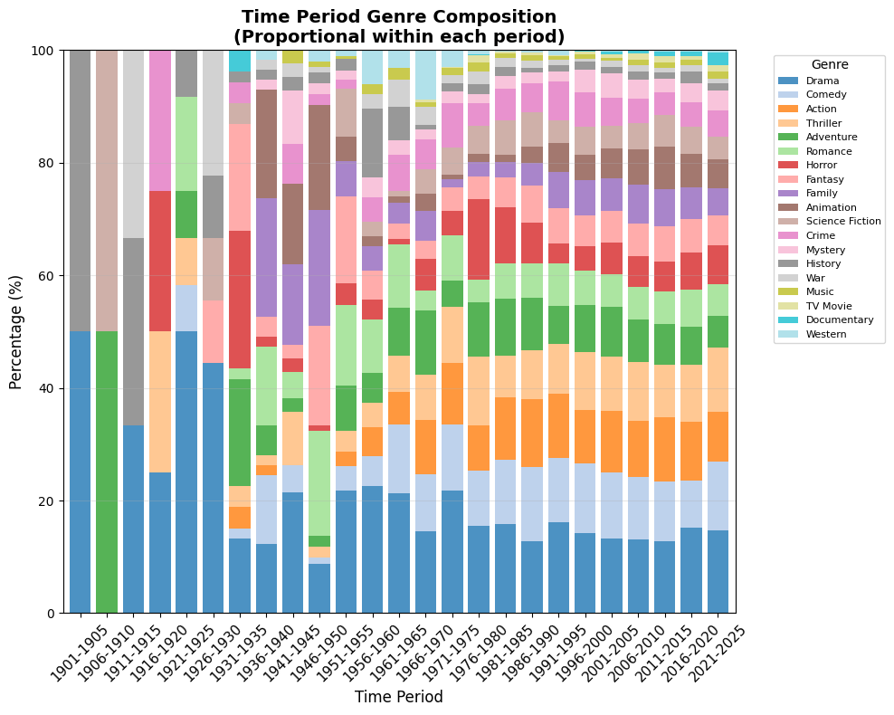

```python
# Calculate genre counts for each time period
time_periods = df['year_group_label'].unique()
genre_by_time = {}
for period in sorted(time_periods):
    genre_by_time[period] = df[df['year_group_label'] == period][all_genres].sum()

# Create DataFrame for time periods
time_counts_df = pd.DataFrame(genre_by_time)

# Sort by total count across all periods for better visualization
time_counts_df['Total'] = time_counts_df.sum(axis=1)
time_counts_df_sorted = time_counts_df.sort_values('Total', ascending=False).drop('Total', axis=1)

fig, ax4 = plt.subplots(1, 1, figsize=(10, 8))

# Proportional view by time period
time_props_df = time_counts_df_sorted.T.div(time_counts_df_sorted.T.sum(axis=1), axis=0) * 100
time_props_df.plot(kind='bar', stacked=True, ax=ax4,
                   colormap='tab20', width=0.8, alpha=0.8)
ax4.set_title("Time Period Genre Composition\n(Proportional within each period)",
              fontsize=14, fontweight='bold')
ax4.set_xlabel('Time Period', fontsize=12)
ax4.set_ylabel('Percentage (%)', fontsize=12)
ax4.legend(title='Genre', bbox_to_anchor=(1.05, 1), loc='upper left', fontsize=8)
ax4.tick_params(axis='x', rotation=45, labelsize=11)
ax4.set_ylim(0, 100)
ax4.grid(True, alpha=0.3, axis='y')

plt.tight_layout()
plt.show()
```

This stacked bar chart illustrates the distribution of movie genres over years: from 1900 to 2025.

We can see that genre composition changes over time. The mix in recent years differs from the 1930s. For instance, Family/Animation account for a large share in the 1930–1950 periods, then drop sharply thereafter; while they tick up a bit after the 1980s, they remain well below early levels. Romance also declines over time and appears relatively stable at a lower share in recent decades.

That said, since the 1980s the overall mix looks more stable: many genres (such as Fantasy, Action, and Thriller) maintain similar proportions across periods, suggesting a more diversified but steady distribution in the modern era.

### Question 2: What are the main factors that influence the box office?

To identify the factors that influence box office performance, we will create four scatter plots with regression lines to examine the relationships between key variables and box office revenue.

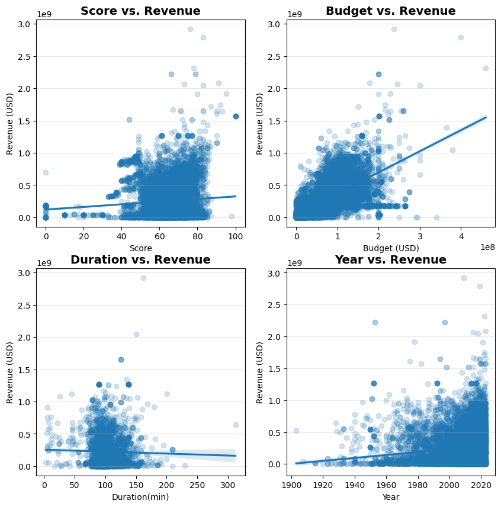

```python
fig, ((ax1, ax2), (ax3, ax4)) = plt.subplots(2, 2, figsize=(10, 10))

# Score vs. Revenue
sns.regplot(x=df['score'], y=df['revenue'], ax = ax1, scatter_kws={'alpha': 0.2})
ax1.set_title('Score vs. Revenue',fontsize=14, fontweight='bold')
ax1.set_xlabel('Score')
ax1.set_ylabel('Revenue (USD)')
ax1.grid(True, alpha=0.3, axis='y')

# Budget vs. Revenue
sns.regplot(x=df['budget'], y=df['revenue'], ax = ax2, scatter_kws={'alpha': 0.2})
ax2.set_title('Budget vs. Revenue',fontsize=14, fontweight='bold')
ax2.set_xlabel('Budget (USD)')
ax2.set_ylabel('Revenue (USD)')
ax2.grid(True, alpha=0.3, axis='y')

# Duration vs. Revenue
sns.regplot(x=df['duration(min)'], y=df['revenue'], ax = ax3, scatter_kws={'alpha': 0.2})
ax3.set_title('Duration vs. Revenue',fontsize=14, fontweight='bold')
ax3.set_xlabel('Duration(min)')
ax3.set_ylabel('Revenue (USD)')
ax3.grid(True, alpha=0.3, axis='y')

# Year vs. Revenue
sns.regplot(x=df['year'], y=df['revenue'], ax = ax4, scatter_kws={'alpha': 0.2})
ax4.set_title('Year vs. Revenue',fontsize=14, fontweight='bold')
ax4.set_xlabel('Year')
ax4.set_ylabel('Revenue (USD)')
ax4.grid(True, alpha=0.3, axis='y')
```

**Budget vs. Revenue**

Both the scatter and the trend line show a clear positive association: films with higher budgets generally earn higher revenues, though the spread remains large.

**Duration vs. Revenue**

Neither the slope nor the point cloud indicates a meaningful relationship between runtime and revenue.

**Year vs. Revenue**

The slope is positive, indicating that average revenues have risen over time. Recent films show higher potential revenues and a wider range (the upper tail grows).

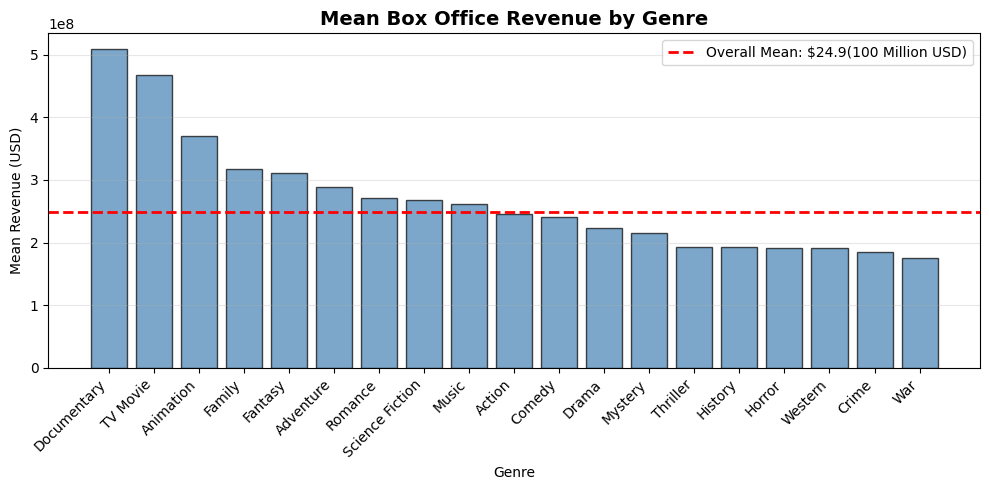

```python
# Calculate mean revenue for each genre
genre_revenues = {}
genre_counts = {}

for genre in all_genres:
    genre_movies = df[df[genre] == 1]['revenue']
    genre_revenues[genre] = {
        'Mean_Revenue': genre_movies.mean()
    }

# Create DataFrame for easier plotting
revenue_comparison = pd.DataFrame({
    'Genre': all_genres,
    'Mean_Revenue': [genre_revenues[g]['Mean_Revenue'] for g in all_genres]
})

# Sort by mean revenue with genre
revenue_comparison = revenue_comparison.sort_values('Mean_Revenue', ascending=False)

# plotting
fig, ax1 = plt.subplots(1, 1, figsize=(10, 5))
ax1.bar(range(len(revenue_comparison)), revenue_comparison['Mean_Revenue'],
        color='steelblue', alpha=0.7, edgecolor='black')
ax1.set_title('Mean Box Office Revenue by Genre', fontsize=14, fontweight='bold')
ax1.set_xlabel('Genre')
ax1.set_ylabel('Mean Revenue (USD)')
ax1.set_xticks(range(len(revenue_comparison)))
ax1.set_xticklabels(revenue_comparison['Genre'], rotation=45, ha='right')
ax1.axhline(y=df['revenue'].mean(), color='red', linestyle='--', linewidth=2,
            label=f'Overall Mean: ${df['revenue'].mean()/10_000_000:.1f}(100 Million USD)')
ax1.legend()
ax1.grid(True, alpha=0.3, axis='y')
plt.tight_layout()
plt.show()
```

This histogram shows the distribution of mean movie revenue in different genres and the red line shows the overall movie revenue mean. We can observe that different genre do have different mean of revenue. In other words, the box office revenue is affected by the genre. For example, in the plot, the documentary and tv movie can earn the highest revenue, while the war earn the lowest.

### Question 3: Do streaming platforms show specific preferences in the genres of movies they make available?

Since we also want to explore the preferences of streaming platforms, such as which genres they favor, we created a stacked bar chart that shows the number of movies in each genre across the different streaming apps.

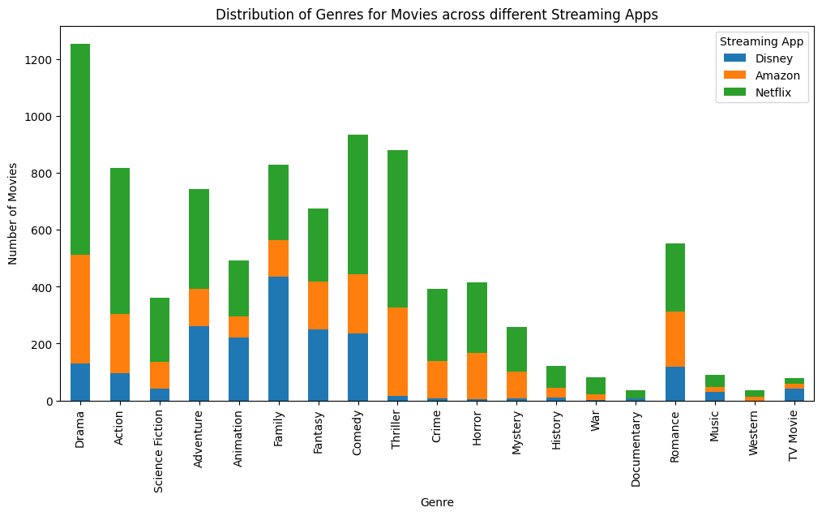

```python
count_disney = df[df['app'] == 'Disney'][all_genres].sum()
count_amazon = df[df['app'] == 'Amazon'][all_genres].sum()
count_netflix = df[df['app'] == 'Netflix'][all_genres].sum()

# Create DataFrame
counts_df = pd.DataFrame({
    'Disney': count_disney,
    'Amazon': count_amazon,
    'Netflix': count_netflix
})

counts_df.plot(kind='bar', stacked = True, figsize=(12,6))
plt.title("Distribution of Genres for Movies across different Streaming Apps")
plt.xlabel('Genre')
plt.ylabel('Number of Movies')
plt.legend(title='Streaming App')
plt.show()
```

In this plot, platforms show both shared and distinct preferences. All three carry relatively few Music, Western, and TV Movies. Amazon and Netflix feature a larger share of Drama and Thriller, whereas Disney has very little Thriller and comparatively favors Family and Fantasy.

## Comparative analysis

### Question 1: What are the differences in people's preferences for genres of movies over time?

In this section, we will explore how audience preferences for movie genres have changed across different time periods. We use the IMDB dataset to compare the average ratings and production volumes of different genres across years. By analyzing these trends, we aim to understand whether certain genres have become more or less popular over time.

```python
genre_trends = []
# Calculate average score for each genre over time periods
for genre in all_genres:
    temp = (
        df[df[genre] == 1]
        .groupby('year_group')['score']
        .mean()
        .reset_index()
        .assign(genre=genre)
    )
    genre_trends.append(temp)

# Concat each dataframe into a complete df.
genre_trends_df = pd.concat(genre_trends, ignore_index=True)
```

```python
# Calculate the top 6 appeared genres
counts = df[all_genres].sum().sort_values(ascending=False)
top_genres = counts.head(6).index

# Contain only the subset within the top genres.
genre_trends_top = genre_trends_df[genre_trends_df['genre'].isin(top_genres)]
genre_trends_top
```

|  | year_group | score | genre |
| --- | --- | --- | --- |
| 0 | 1901 | 63.000000 | Drama |
| 1 | 1911 | 61.000000 | Drama |
| 2 | 1916 | 80.000000 | Drama |
| 3 | 1921 | 70.333333 | Drama |
| 4 | 1926 | 75.250000 | Drama |
| ... | ... | ... | ... |
| 300 | 2001 | 65.406250 | Romance |
| 301 | 2006 | 64.926941 | Romance |
| 302 | 2011 | 64.898876 | Romance |
| 303 | 2016 | 57.626190 | Romance |
| 304 | 2021 | 59.119850 | Romance |

123 rows × 3 columns

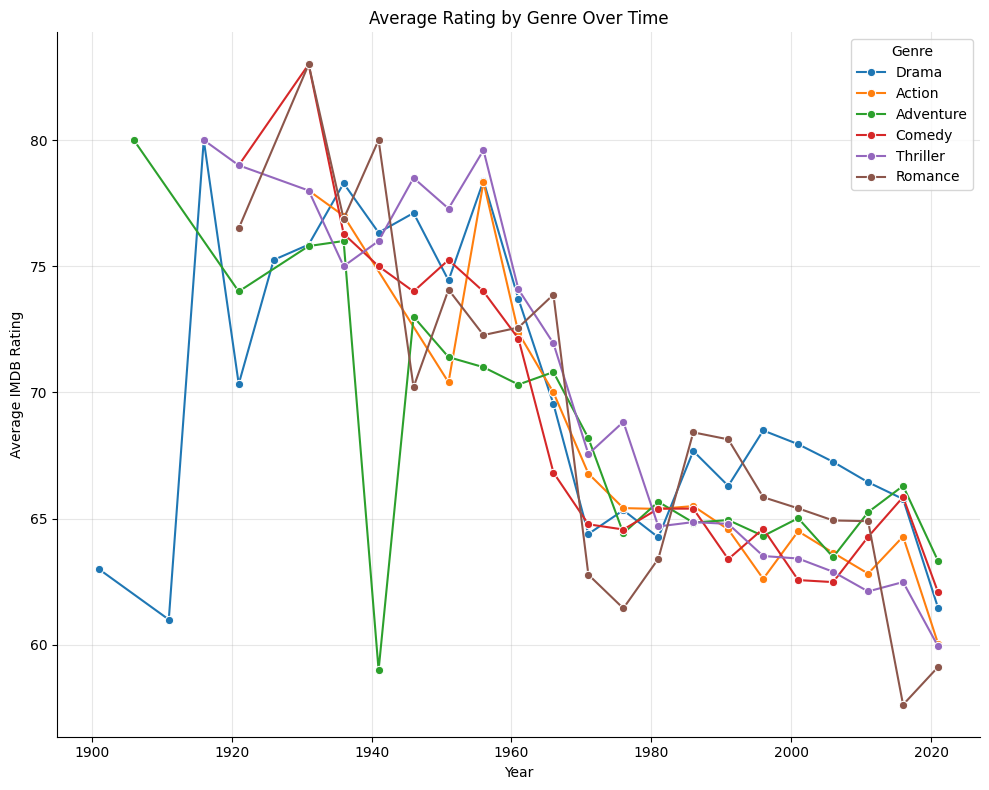

```python
# Plot the line graph for average ratings by genres over time.
plt.figure(figsize = (10, 8))
sns.lineplot(data=genre_trends_top, x='year_group', y='score', hue='genre', marker='o')
plt.title("Average Rating by Genre Over Time")
plt.xlabel("Year")
plt.ylabel("Average IMDB Rating")
plt.legend(title="Genre")
sns.despine()
plt.grid(alpha = 0.3)
plt.tight_layout()
plt.show()
```

In summary, although all genres demonstrate some natural variation, genres like drama and comedy have been popular over time while genres bringing about a sense of excitement like action, adventure and thriller have had more fluctuating reception and preferences over time.

**Proportion of High-Rated Movies**  
To further understand audience preferences, we then analyzed the subset of movies with ratings above the overall mean value (score > 63.69), which shows that which genres tend to generate higher proportion of top-rated films over time.

```python
score_mean = df['score'].mean()
print("Overall average rating:", score_mean)
```

```
Overall average rating: 63.68763845813026
```

```python
# Create a new df that only contains the movies with score higher than mean score.
high_rated_df = df[df['score'] > score_mean]
```

```python
genre_high_ratio = [] # Empty list to store all the dataframes.
for genre in all_genres:
    # Calculate total count of movies for this genre by year group
    temp = (
        df.groupby('year_group')[genre]
        .sum()
        .reset_index()
        .rename(columns={genre: 'total_count'})
    )
    # Calculate count of high-rated movies for this genre by year group
    high_temp = (
        high_rated_df.groupby('year_group')[genre]
        .sum()
        .reset_index()
        .rename(columns={genre: 'high_count'})
    )

    merged = pd.merge(temp, high_temp, on='year_group', how='left').fillna(0)
    merged['genre'] = genre
    # Calculate the ratio of high-rated movies to total movies for this genre
    merged['high_ratio'] = merged['high_count'] / merged['total_count']
    genre_high_ratio.append(merged)

# Combine all individual genre DataFrames into one comprehensive DataFrame
genre_high_ratio = pd.concat(genre_high_ratio, ignore_index=True)
```

```python
top_genres = df[all_genres].sum().sort_values(ascending=False).head(6).index
genre_high_ratio = genre_high_ratio[genre_high_ratio['genre'].isin(top_genres)]
```

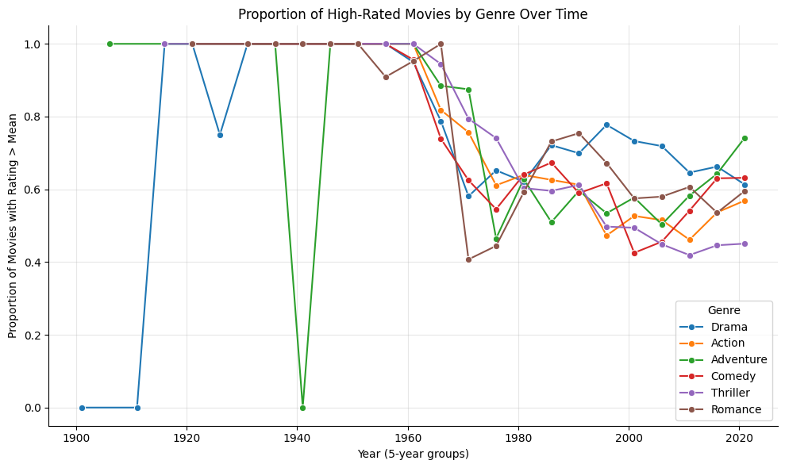

```python
# Plot the line graph for proportion of high-rated movies by genres over time.
plt.figure(figsize = (10, 6))
sns.lineplot(data=genre_high_ratio, x='year_group', y='high_ratio', hue='genre', marker='o')
plt.title("Proportion of High-Rated Movies by Genre Over Time")
plt.xlabel("Year (5-year groups)")
plt.ylabel("Proportion of Movies with Rating > Mean")
plt.legend(title="Genre")
sns.despine()
plt.grid(alpha = 0.3)
plt.tight_layout()
plt.show()
```

Overall, the subset of high ratings films reinforces the previous analysis that according to the ratings on IMDB, people have always had a preference on drama, and had fluctuating attitudes towards films that are exciting, such as action films and adventure films. People's attitudes towards romantic films and comedies are also constantly changing. In short, audience's preference on genres of movies changed a lot over time.

### Question 2: What are the main factors that influence the box office?

In this section, we will explore how box office performances differs across different subsets of data by dividing movies into categories by budget and rating. We will compare how these factors influence revenue distribution.

```python
Q1 = df['revenue'].quantile(0.25)
Q3 = df['revenue'].quantile(0.75)
IQR = Q3 - Q1
```

```python
print(df['budget'].quantile([0.25,0.5,0.75]))
```

```
0.25     13800000.0
0.50     47270000.0
0.75    103600000.0
Name: budget, dtype: float64
```

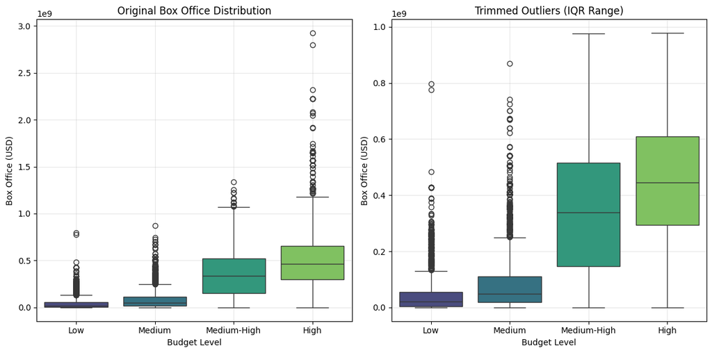

```python
# Divide budget into four quartile groups
df['budget_group'] = pd.qcut(df['budget'], q=4, labels=['Low','Medium','Medium-High','High'])

# Filtered the extreme outliers.
filtered_df = df[
    (df['revenue'] >= Q1 - 1.5 * IQR) &
    (df['revenue'] <= Q3 + 1.5 * IQR)
]

fig, (ax1, ax2) = plt.subplots(1, 2, figsize = (12, 6), sharey = False)

# Create boxplot for box office distribution in different budget groups.
sns.boxplot(data=df, x='budget_group', y='revenue', palette='viridis', ax=ax1)
ax1.set_title("Original Box Office Distribution")
ax1.set_xlabel("Budget Level")
ax1.set_ylabel("Box Office (USD)")
ax1.grid(alpha=0.3)

# Create boxplot for box office distribution in different budget groups (without extreme outliers).
sns.boxplot(data=filtered_df, x='budget_group', y='revenue', palette='viridis', ax=ax2)
ax2.set_title("Trimmed Outliers (IQR Range)")
ax2.set_xlabel("Budget Level")
ax2.set_ylabel("Box Office (USD)")
ax2.grid(alpha=0.3)

plt.tight_layout()
plt.show()
```

```python
# Create a summary table for different budget groups' mean and median revenues.
summary = df.groupby('budget_group')['revenue'].agg(['mean','median','std','count'])
summary
```

| budget_group | mean | median | std | count |
| --- | --- | --- | --- | --- |
| Low | 4.587147e+07 | 20018122.0 | 6.998615e+07 | 2822 |
| Medium | 8.824464e+07 | 48731823.5 | 1.088058e+08 | 2822 |
| Medium-High | 3.527623e+08 | 339269019.4 | 2.407939e+08 | 2825 |
| High | 5.113715e+08 | 463238370.0 | 3.009441e+08 | 2816 |

From the box plots above, we can observe that **films with higher production budgets generate higher median revenues obviously**. After dividing the budget on average into four intervals from low to high, the relationship between budgets and revenues becomes clearer, since each increase in budget category corresponds to a higher box office range, which again indicates that budget is a significant predictor of box office revenue.  
However, we can also observe that the median differences between the **low** and **medium** groups, and the median differences between **medium-high** and **high** groups are not so significant as the median difference between **medium** and **medium-high**. Therefore, we can infer that the 50 million budget represents a turning point. The box office revenues of movies below the median are generally lower, and they are not significantly affected by the budget.

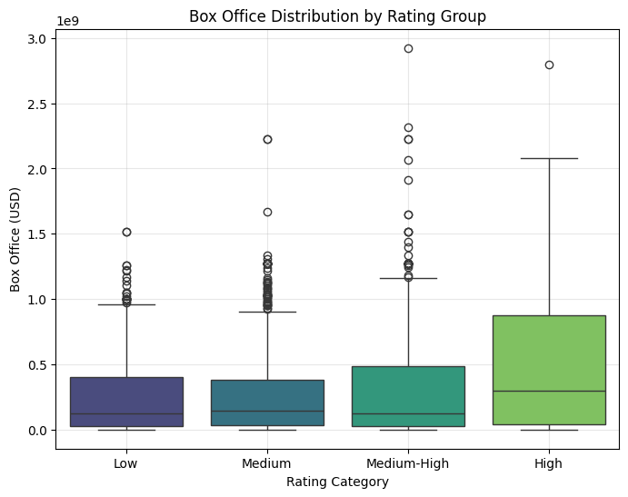

```python
# Divide rating into four intervals
df['rating_group'] = pd.cut(df['score'], bins=[0,60,70,80,100], labels=['Low','Medium','Medium-High','High'])

# Create the boxplot for box office distribution by rating group.
plt.figure(figsize = (8, 6))
sns.boxplot(data=df, x='rating_group', y='revenue', palette='viridis')
plt.title("Box Office Distribution by Rating Group")
plt.xlabel("Rating Category")
plt.ylabel("Box Office (USD)")
plt.grid(alpha = 0.3)
plt.show()
```

```python
# Create a summary table for different rating groups' mean and median revenues.
summary = df.groupby('rating_group')['revenue'].agg(['mean','median','std','count'])
summary
```

| rating_group | mean | median | std | count |
| --- | --- | --- | --- | --- |
| Low | 2.386830e+08 | 120023179.0 | 2.664171e+08 | 3148 |
| Medium | 2.279865e+08 | 145307784.2 | 2.380437e+08 | 4722 |
| Medium-High | 2.761188e+08 | 123954323.0 | 3.104852e+08 | 2881 |
| High | 4.950219e+08 | 299461782.0 | 5.176833e+08 | 317 |

Next, we further apply ANOVA and Tukey's HSD to examine the differences among the various rating groups.

```python
# ANOVA for rating groups
import statsmodels.api as sm
from statsmodels.formula.api import ols
from scipy.stats import f_oneway

# Clean the nan values.
df_clean = df.dropna(subset=['rating_group'])
groups = [df_clean[df_clean['rating_group']==g]['revenue'] for g in df_clean['rating_group'].unique()]
f_stat, p_val = f_oneway(*groups)
print(f"ANOVA result for Rating Groups: F={f_stat:.2f}, p={p_val:.4f}")

model_anova = ols('revenue ~ C(rating_group)', data=df_clean).fit()
anova_table = sm.stats.anova_lm(model_anova, typ=2)
anova_table
```

```
ANOVA result for Rating Groups: F=102.32, p=0.0000
```

|  | sum_sq | df | F | PR(>F) |
| --- | --- | --- | --- | --- |
| C(rating_group) | 2.367205e+19 | 3.0 | 102.323092 | 2.462620e-65 |
| Residual | 8.532044e+20 | 11064.0 | NaN | NaN |

```python
# Tukey's HSD for rating groups to determine if there are significant differences.
from statsmodels.stats.multicomp import pairwise_tukeyhsd

tukey = pairwise_tukeyhsd(df_clean['revenue'], groups=df_clean['rating_group'])
print(tukey)
```

```
              Multiple Comparison of Means - Tukey HSD, FWER=0.05
================================================================================
group1    group2       meandiff    p-adj       lower           upper      reject
--------------------------------------------------------------------------------
  High         Low -256338868.0662    0.0 -298383499.9163 -214294236.2162   True
  High      Medium -267035352.8861    0.0 -308433936.6493 -225636769.1229   True
  High Medium-High -218903092.3695    0.0 -261125587.7653 -176680596.9736   True
   Low      Medium  -10696484.8199 0.3375  -27114208.4455    5721238.8057  False
   Low Medium-High   37435775.6967    0.0   19039090.4274   55832460.9661   True
Medium Medium-High   48132260.5167    0.0   31264252.3624   65000268.6709   True
--------------------------------------------------------------------------------
```

Finally, let's examine the impact of genre on box office receipts by applying ANOVA and Tukey's HSD.

```python
# ANOVA test for different genres.
groups = [df.loc[df[g]==1, 'revenue'].dropna() for g in top_genres]
f_stat, p_val = f_oneway(*groups)
print(f"ANOVA across top genres: F={f_stat:.2f}, p={p_val:.4f}")
```

```
ANOVA across top genres: F=38.43, p=0.0000
```

```python
# Extract the first genre as the main genre for easy analysis.
df['main_genre'] = df['genre'].astype(str).str.split(',').str[0].str.strip()
df_clean_genres = df.dropna(subset=['main_genre'])

# Apply Tukey's HSD.
tukey_genres = pairwise_tukeyhsd(df_clean_genres['revenue'], groups=df_clean_genres['main_genre'])
tukey_df = pd.DataFrame(data=tukey_genres._results_table.data[1:], columns=tukey_genres._results_table.data[0])
significant_genres = tukey_df[tukey_df['reject'] == True]
significant_genres
```

|  | group1 | group2 | meandiff | p-adj | lower | upper | reject |
| --- | --- | --- | --- | --- | --- | --- | --- |
| 1 | Action | Animation | 1.510391e+08 | 0.0000 | 1.122596e+08 | 1.898185e+08 | True |
| 3 | Action | Crime | -5.809136e+07 | 0.0109 | -1.099334e+08 | -6.249292e+06 | True |
| 4 | Action | Documentary | 2.765077e+08 | 0.0000 | 2.046668e+08 | 3.483486e+08 | True |
| 6 | Action | Family | 1.366429e+08 | 0.0000 | 8.395599e+07 | 1.893297e+08 | True |
| 9 | Action | Horror | -5.627559e+07 | 0.0000 | -9.341181e+07 | -1.913936e+07 | True |
| ... | ... | ... | ... | ... | ... | ... | ... |
| 180 | TV Movie | Thriller | -2.227832e+08 | 0.0001 | -3.773259e+08 | -6.824038e+07 | True |
| 181 | TV Movie | War | -2.250732e+08 | 0.0028 | -4.103206e+08 | -3.982587e+07 | True |
| 182 | TV Movie | Western | -2.685671e+08 | 0.0001 | -4.546707e+08 | -8.246355e+07 | True |
| 186 | Thriller | nan | 1.409712e+08 | 0.0011 | 3.010289e+07 | 2.518396e+08 | True |
| 189 | Western | nan | 1.867552e+08 | 0.0022 | 3.495645e+07 | 3.385540e+08 | True |

87 rows × 7 columns

With the ANOVA's result, we know that there are differences between different genres. With further Tukey's HSD analysis, most of film genres have demonstrated differences in their box office performances.

### Question 3: Do streaming platforms show specific preferences in the genres of movies they make available?

In this section, we will analyze whether or not different streaming platforms show specific preferences in the genres of movies they make available by comparing the genre composition across different platforms. First, we will try to compare the ratings of different genres of movies on these streaming platforms.

```python
# Create a new df without NaN values in 'app'.
df_platform = df.dropna(subset=['app'])
```

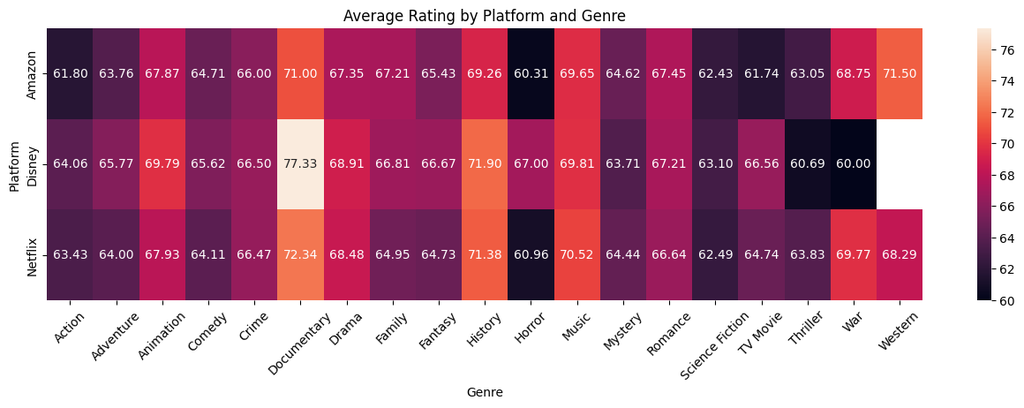

```python
# Create a new df with only some certain columns.
platform_genre_rating = pd.DataFrame({'platform': df_platform['app'],'rating': df_platform['score']})

for g in all_genres:
    platform_genre_rating[g] = df_platform[g]

# Reshape the data and obtain the mean ratings for different platforms across different genres.
platform_genre_rating = (platform_genre_rating.melt(id_vars=['platform','rating'], var_name='Genre',
                                                    value_name='is_genre').query('is_genre == 1').
                            groupby(['platform','Genre'])['rating'].mean().unstack())

plt.figure(figsize = (16, 4))
sns.heatmap(platform_genre_rating, annot=True, fmt=".2f")
plt.title("Average Rating by Platform and Genre")
plt.xlabel("Genre")
plt.ylabel("Platform")
plt.xticks(rotation=45)
plt.show()
```

We use the heatmap to compare the average IMDB ratings of different genres across the three major streaming platforms: Netflix, Amazon and Disney+. From the heatmap graph, we cannot observe any obvious differences in the ratings. But we can still find some patterns.

1. Disney+ achieves relatively higher ratings in documentary, history, animation and music, which is consistent with its traditional focus.
2. Amazon shows higher ratings in western films.
3. Netflix displays higher ratings in history, music, war and western.

The rating differences between Amazon and Netflix are not exactly the same as our perception of them. The small number of samples and the relatively even distribution of scores (mostly within 60-70) can be the possible reasons.

Next, we will compare the proportion of each genre of films on different platforms.

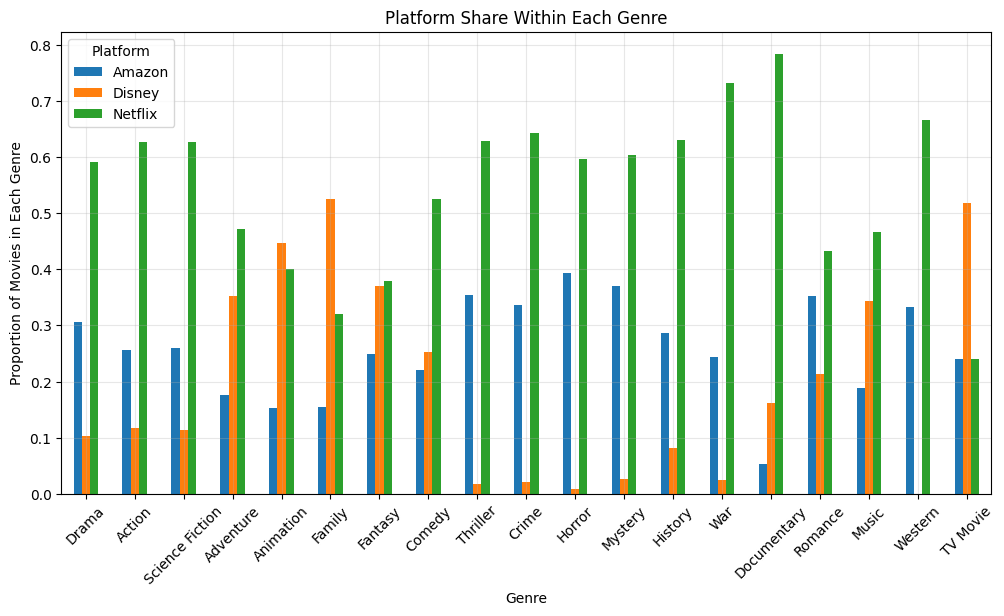

```python
# Calculate the count of movies in each genre for each platform
genre_counts = df_platform.groupby('app')[all_genres].sum()
# Calculate the platform share within each genre
platform_share = genre_counts.div(genre_counts.sum(axis=0), axis=1)

platform_share.T.plot(kind = 'bar', figsize = (12, 6))
plt.title("Platform Share Within Each Genre")
plt.xlabel("Genre")
plt.ylabel("Proportion of Movies in Each Genre")
plt.xticks(rotation=45)
plt.legend(title="Platform")
plt.grid(alpha=0.3)
plt.show()
```

## Multivariate analysis

### Question 1: What are the differences in people's preferences for genres of movies over time?

```python
# Reshape the DataFrame from wide to long format, filter to keep only rows with is_genre = 1.
long_df = df.melt(id_vars=['year_group','score'], value_vars=all_genres,
                    var_name='Genre', value_name='is_genre').query('is_genre == 1')

# Create a pivot table to calculate average ratings
pivot_table = pd.pivot_table(long_df, values='score', index='year_group',
                            columns='Genre', aggfunc='mean').round(2)
```

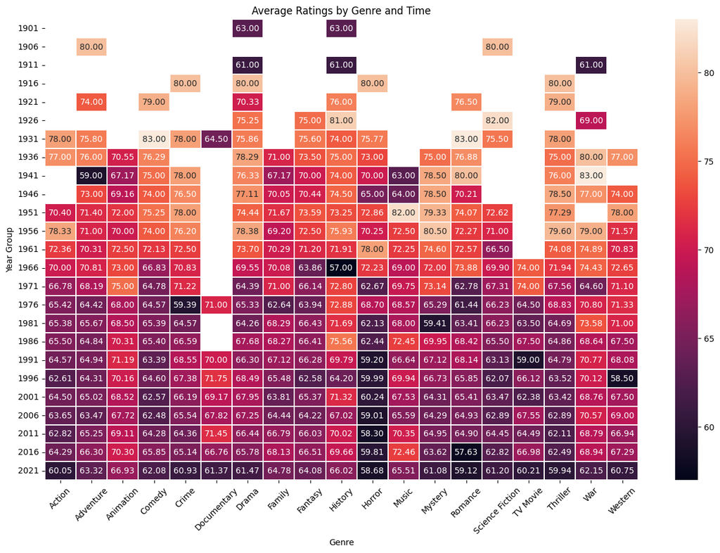

```python
# Create a heatmap for the pivot table for better understanding.
plt.figure(figsize = (16, 10))
sns.heatmap(pivot_table, linewidths=0.3, annot=True, fmt=".2f")
plt.title("Average Ratings by Genre and Time")
plt.xlabel("Genre")
plt.ylabel("Year Group")
plt.xticks(rotation=45)
plt.show()
```

With the pivot tables and heatmap above, we analyze the multivariate relationship among average rating, year and genres. We have found the following patterns:

1. Animation, documentary, drama and music: these genres have consistently received relatively high ratings during the same year group and have been favored by the audience.
2. Romance and comedy, horror and thriller: the popularity of these genres has been continuously declining recently.
3. Action and Adventure: these genres' popularity fluctuates significantly.

These multivariate relationship shows how time and genre jointly shape audience's preferences, which further demonstrates that audience's preferences for genres change over time.

### Question 2: What are the main factors that influence the box office?

```python
# Create a pivot table to calculate average revenue by budget groups and rating groups.
pivot_revenue = pd.pivot_table(df_clean, values='revenue', index='budget_group',
                                columns='rating_group', aggfunc='mean', observed=False)
pivot_revenue
```

| rating_group budget_group | Low | Medium | Medium-High | High |
| --- | --- | --- | --- | --- |
| Low | 2.477468e+07 | 6.383448e+07 | 4.263640e+07 | 5.839518e+07 |
| Medium | 5.993604e+07 | 9.196302e+07 | 1.020200e+08 | 1.427505e+08 |
| Medium-High | 3.346515e+08 | 3.172224e+08 | 4.274226e+08 | 6.502361e+08 |
| High | 4.771653e+08 | 4.831551e+08 | 6.204293e+08 | 9.937412e+08 |

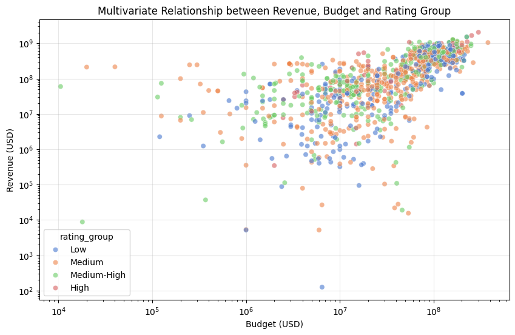

```python
# Sample 10% data for better visualization. seed 42 for reproducible result.
sample_df = df_clean.sample(frac=0.1, random_state=42)

# Create a scatter plot for revenue by rating and budget.
plt.figure(figsize = (10, 6))
sns.scatterplot(data=sample_df, x='budget', y='revenue', hue='rating_group', alpha=0.6, palette='muted')
plt.title("Multivariate Relationship between Revenue, Budget and Rating Group")
plt.xlabel("Budget (USD)")
plt.ylabel("Revenue (USD)")

# Apply logarithmic scaling to better visualize wide data ranges
plt.xscale('log')
plt.yscale('log')
plt.grid(alpha = 0.3)
plt.show()
```

With the pivot table and scatter plot above, we analyze the multivariate relationship among revenue, budget and rating. To improve visibility of the multivariate scatterplot, we randomly sampled 10% of the data and applied log-scaled axes.  
We have found that **films with high budget and high rating generate the highest average revenue**. Even for films with lower budget, high-group ratings still improve revenue performance. However, we also find that in medium-high budget group, the average box office of low rating films is roughly the same as that of medium rating films.  
Overall, the budget investment and audience preferences jointly determine the box office success or failure.

### Question 3: Do streaming platforms show specific preferences in the genres of movies they make available?

```python
# Reshape the DataFrame from wide to long format, filter to keep only rows with is_genre = 1.
long_df_2 = df.melt(id_vars=['app','revenue'], value_vars=all_genres,
                    var_name='Genre', value_name='is_genre').query('is_genre==1')

# Create a pivot table to calculate average revenues.
pivot_rev = pd.pivot_table(long_df_2, values='revenue', index='app',
                            columns='Genre', aggfunc='mean').round(2)

pivot_rev
```

| Genre app | Action | Adventure | Animation | Comedy | Crime | Documentary | Drama | Family | Fantasy | History | Horror | Music | Mystery | Romance | Science Fiction | TV Movie | Thriller | War | Western |
| --- | --- | --- | --- | --- | --- | --- | --- | --- | --- | --- | --- | --- | --- | --- | --- | --- | --- | --- | --- |
| Amazon | 1.710467e+08 | 2.109921e+08 | 3.190512e+08 | 1.611822e+08 | 1.380990e+08 | 3.554356e+08 | 1.829170e+08 | 2.938233e+08 | 3.333185e+08 | 1.780582e+08 | 1.421775e+08 | 8.225328e+07 | 1.518879e+08 | 3.096479e+08 | 1.824815e+08 | 3.878204e+08 | 1.563577e+08 | 9.009103e+07 | 1.867917e+08 |
| Disney | 3.397209e+08 | 3.388614e+08 | 3.872757e+08 | 2.859643e+08 | 2.292086e+08 | 4.206512e+08 | 3.775337e+08 | 3.381782e+08 | 3.878342e+08 | 2.013809e+08 | 4.895918e+08 | 2.956138e+08 | 3.289305e+08 | 4.468746e+08 | 3.258789e+08 | 4.650910e+08 | 2.726142e+08 | 5.727694e+07 | NaN |
| Netflix | 2.020431e+08 | 2.380711e+08 | 3.099795e+08 | 2.020107e+08 | 1.481915e+08 | 3.974125e+08 | 1.660528e+08 | 2.544369e+08 | 2.385443e+08 | 1.622390e+08 | 1.620893e+08 | 2.947750e+08 | 1.754259e+08 | 1.786207e+08 | 2.064552e+08 | 3.621338e+08 | 1.612933e+08 | 1.338856e+08 | 1.906216e+08 |

From the pivot table above, we analyze the multivariate relationship among platforms, genres and revenues. We can find that Netflix shows a higher preference in war films with higher revenues. For all other types, Disney+ shows a preference for high box-office-revenues films. Therefore, we can observe that the box office figures have an impact on the platform's preference for certain types of films.

## Synthesis

### Question 1: What are the differences in people's preferences for genres of movies over time?

From the descriptive analysis, we know our years span 1900 to 2025. In the inferential studies, with multiple chi-square tests performed, we see that people’s preferences for movie genres change over time. In the graphical analysis, the information shown aligns with the results from the descriptive and inferential analyses: the plots cover 1900–2025, and we see different genre preferences in recent years compared to the 1930s.

### Question 2: What are the main factors that influence the box office?

From the descriptive analysis, we infer that revenue is right-skewed, which is consistent with the revenue pattern visible in the scatter plot. The distributions of score, budget, and duration also align with what we see in the plots. In the inferential analysis, we conclude that there are relationships between score and revenue, budget and revenue, and genre and revenue. However, in the scatter plots, only the budget–revenue and genre–revenue relationships appear visually clear; the score–revenue relationship remains less obvious in the visualization.

### Question 3: Do streaming platforms show specific preferences in the genres of movies they make available?

In the descriptive analysis, we observe that most releases fall into Drama, Comedy, Action, and Thriller. This largely matches the bar chart, where Drama, Comedy, and Thriller have the tallest bars.

From the chi-square tests, we find a significant association between streaming platform and genre—i.e., platforms differ in their genre preferences. The plot reflects this: platforms show distinct genre mixes (e.g., Disney favors Family, while Netflix leans toward Drama).

### Advantage of the combination of the dataset

By combining the datasets, we can address Question 3. Looking separately at the Amazon, Disney, and Netflix data lets us see each platform’s catalog composition. Merging these with the main IMDb dataset then allows us to assess whether streaming platforms have distinct preferences in the genres of the movies they make available.

Additionally, duration is recorded only in the Amazon, Disney, and Netflix datasets (not in the main one). This lets us investigate whether runtime has any impact on box-office revenue.

# Reflection

During the process of analyzing the data, we have endeavored to address our three real-world questions comprehensively that we are interested in. We encountered many difficulties and overcame them one by one.

**Challenges Encountered and Solutions:**

1. Our dataset contains over 10,000 rows, which often led to issues with cluttered and dense data points, making trends difficult to observe in scatter plots. To address this, we applied data binning, which significantly reduced the number of data categories and made both analysis and visualization much clearer and more efficient.
2. Movies always belong to more than one genres, which prevented us from directly extracting the genre of the films and conducting analyses. To solve this problem, we adopted one-hot encoding and chose to retain all the sub-genres of movies to ensure the integrity of the data.
3. The dataset spans a wide time period, but the number of records for earlier decades is limited, resulting in an imbalance in temporal analyses. To mitigate this issue, we grouped the years into five-year intervals, which helped maintain stability and comparability across time.
4. Due to the large number of unique genres, some pivot tables were too extensive to interpret directly. To improve readability and highlight relationships more effectively, we used heatmaps to visualize multivariate relationships clearly and intuitively.
5. Some variables were not statistically significant and did not meet our initial expectations, limiting the strength of our conclusions. To address this, we conducted a deeper investigation into the relationships between strongly correlated variables and explored additional potential factors that might influence the results.

**Evaluation of Limitations:**

1. Limited factors considerations. Factors like directors and main casts were not included in the box office analysis, but we still believe that they might have an impact on box office results.
2. Limited platform data. In our dataset, only about one-third of the entries include information on the platform where the movie was made available, which may only partially reflect the platform’s preferences.
3. Simplified genre analyses. By using one-hot encoding and analyzing each genre of movie separately, we are likely to overlook the relationships and nuances among movies that belong to multiple genres.

**Suggested Future Research and Improvement:**

1. Further expand the datasets. Beyond the current 10,000 rows of data, we can enhance the comprehensiveness of our analysis by collecting additional movie information via the IMDb API or automated data extraction scripts.
2. Consider more factors. By considering additional factors such as the director and the main cast, we can obtain a more nuanced and comprehensive analysis of the data.

In general, we successfully addressed the three practical issues we had raised and practiced the skills related to data analysis.